```python
from IPython.display import Image
```

# Support Vector Machines - Theory

## Support Vector Machines (SVMs) - Introduction

The goal of an SVM is to find a hyperplane in an $N$-dimensional space (where $N$ is the number of features) that distinctly classifies a set of data points.

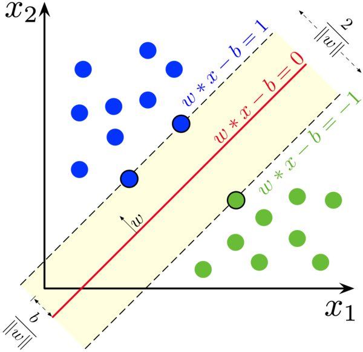

```python
Image('img/svm_example.png')
```

Source: Wikipedia

The red line represents the hyperplane. As seen, it is drawn at an equal distance between the blue and green classes. Here, this is the maximum margin between the two classes, making it the optimal hyperplane for separating the data.

## Hinge Loss

In an SVM, we aim to maximize the margin between the data points and the hyperplane. The loss function used to maximize the margin is known as **hinge loss**.

$c(x,y,f(x)) = \begin{cases} 0\:,\:if\: y*f(x)\geq1\\ 1-y*f(x)\:,\:otherwise \end{cases}$

This function can also be regularized with L1 and L2 norms in the same way as in linear regression. Here is the L2 norm:

- $\frac{1}{2}\sum_{i=1}^{n}(1-f(x))^2$

### Where does $f(x)$ come from?

$f(x)$ is a **kernel function**. This is basically the function that the hyperplane is built off of, and can be either linear or non-linear. In the example above, the kernel function would be linear.

Below is an example where we would want a non-linear SVM:

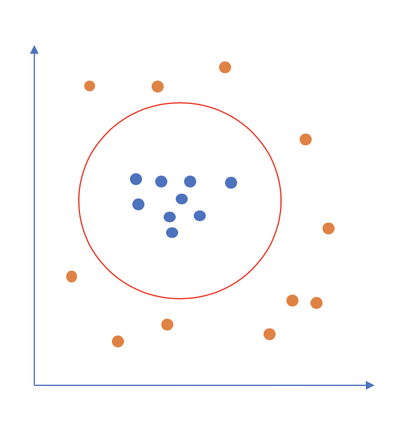

```python
Image('img/non_linear_svm.png')
```

Here, the red circle represents the hyperplane.

## Kernel Functions

The three most popular types of kernels are:

- Linear Kernel
- Polynomial Kernel
- Gaussian Kernel

In the examples below, $X_1$ and $X_2$ represent feature vectors. The $\cdot$ refers to dot products.

### Linear Kernel

$K(X_1,X_2)=X_1\cdot X_2$

### Polynomial Kernel

$K(X_1,X_2)=(\alpha+X_1^T\cdot X_2)^b$, where $b$ is the degree of the kernel and $\alpha$ is a constant term

### Gaussian Kernel

$K(X_1,X_2)=exp(\frac{-1}{2\sigma^2}||X_1-X_2||^2)$ where $||X_1-X_2||$ represents the Euclidean distance between $X_1$ and $X_2$

This is the most popular type of non-linear kernel.

- Calculated using the Euclidean distance of two vectors and a parameter $\sigma$ that describes the smoothness of the function.
- As $\sigma^2$ increases, the bias increases and the variances decreases

Is also known as a **Radial Basis Function (RBF) Kernel**. Here, we just say $\gamma=\frac{1}{2\sigma^2}$. So, the kernel function is:

- $K(X_1,X_2)=exp(-\gamma||X_1-X_2||^2)$

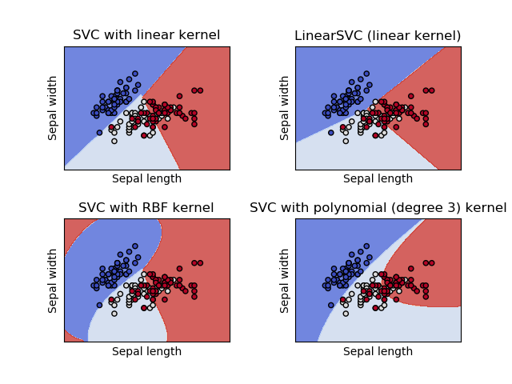

```python
Image("img/kernel_examples.png")
```

Source: sklearn documentation

## Pros and Cons of SVMs

### Pros

- Works more effectively in high dimension spaces, particular when there are more features than training instances
- Relatively memory efficient
- Very good when there is a clear margin of separation between classes

### Cons

- Not suitable for large datasets due to compute time
- Can overfit if number of features are significantly greater than number of training instances
- Does not perform well when the dataset is noisy (i.e. target classes are overlapping)
- Selecting appropriate kernel function can be tricky
- Does not provide class probabilities

## More Resources

[In-depth look at SVM](https://towardsdatascience.com/optimization-loss-function-under-the-hood-part-iii-5dff33fa015d)

[Another great explanation of SVMs](https://towardsdatascience.com/support-vector-machines-svm-c9ef22815589)